# Итоговое задание по курсу АОТ

### Язык программирования python3 (задание E, пункт 2: тематическая классификация на основе векторной модели текста)

*Импортируем все необходимые модули для парсинга текстов, извлечения векторов из текста, классификаторы и метрики.*

```python
from sklearn.datasets import fetch_20newsgroups
from sklearn import metrics
from sklearn.feature_extraction.text import TfidfVectorizer, CountVectorizer
from sklearn.model_selection import GridSearchCV
from sklearn.ensemble import RandomForestClassifier
from sklearn.svm import SVC
from sklearn.linear_model import LogisticRegression
from sklearn.model_selection import StratifiedKFold
from sklearn.metrics import accuracy_score
from sklearn.metrics import classification_report, roc_auc_score, roc_curve
from matplotlib import pyplot as plt
import nltk
from nltk.stem import WordNetLemmatizer
from nltk import pos_tag
from nltk.corpus import stopwords
import numpy as np
import re
from collections import OrderedDict
```

*Зададим стоп-лист*

```python
ignore_symbs = [',', '-', ':', '!', ';', '(', ')', '–', '"', '{', '}', '[', ']', '.', '?', '@',
                '<', '>', '|', '*', '...']
stop = set(stopwords.words('english'))
stop.update(ignore_symbs)
```

## Подготовка

### Напишем несколько классов для подготовки текстов. Класс FinalHWData аггрегирует размеченные тексты из модуля datasets. Функция fetch_20newsgroups возвращает тексты на выбор из 20 имеющихся категорий, которые мы определим позже

```python
class FinalHWData(object):

    def __init__(self, categories, remove):
        self.categories = categories
        self.remove = remove
        self._init_data()

    def _init_data(self):
        self.train = fetch_20newsgroups(subset='train', categories=cats,
                                        remove=('headers', 'footers', 'quotes'))
        self.test = fetch_20newsgroups(subset='test', categories=cats,
                                       remove=('headers', 'footers', 'quotes'))
        self.train_target = self.train.target
        self.test_target = self.test.target

    def get_data(self, kind):
        if kind.lower() == 'test':
            return self.test.data
        elif kind.lower() == 'train':
            return self.train.data

    def get_target(self, kind):
        if kind.lower() == 'test':
            return self.test.target
        elif kind.lower() == 'train':
            return self.train.target
```

### Класс DataPreparator нормализует данные и фильтрует слова из стоп-листа

```python
class DataPreparator(object):

    def __init__(self):
        self.train_normal = []
        self.test_normal = []

    def normalize(self, train, test, stop_words):
        for text in train:
            tokens = nltk.word_tokenize(text)
            tokens = list(filter(lambda x: x not in stop_words, tokens))
            wnl = WordNetLemmatizer()
            normal_form_list = [wnl.lemmatize(i, j[0].lower()) if j[0].lower() in ['a', 'n', 'v']
                                else wnl.lemmatize(i) for i, j in pos_tag(tokens)]
            normal_form = ' '.join(normal_form_list)
            normal_form = re.sub(r'\d+', '', normal_form.replace('*', ''))
            self.train_normal.append(normal_form)

        for text in test:
            tokens = nltk.word_tokenize(text)
            tokens = list(filter(lambda x: x not in stop_words, tokens))
            wnl = WordNetLemmatizer()
            normal_form_list = [wnl.lemmatize(i, j[0].lower()) if j[0].lower() in ['a', 'n', 'v']
                                else wnl.lemmatize(i) for i, j in pos_tag(tokens)]
            normal_form = ' '.join(normal_form_list)
            normal_form = re.sub(r'\d+', '', normal_form.replace('*', ''))
            self.test_normal.append(normal_form)

    def get_data(self, kind):
        if kind.lower() == 'train':
            return self.train_normal
        elif kind.lower() == 'test':
            return self.test_normal
```

### Класс ModelBuilder получает на вход количество фолдов для кросс-валидации, список моделей и параметры, после чего с помощью функции GridSearchCV из фреймворка scikit-learn выбирает по сетке параметров наилучшую модель, ориентируясь на accuracy скоринг

```python
class ModelBuilder(object):

    def __init__(self, cv_folds, models, models_names, param_grids):
        self.cv_folds = cv_folds
        self.models = models
        self.models_names = models_names
        self.param_grids = param_grids

    def fit(self, train, target):
        cross_validator = StratifiedKFold(n_splits=self.cv_folds, shuffle=True, random_state=0)
        best_score = 0
        for clf, params, name in zip(self.models, self.param_grids, self.models_names):
            gs = GridSearchCV(estimator=clf, param_grid=params,
                              scoring='accuracy', cv=cross_validator)
            gs.fit(train.toarray(), target)
            print('For {} the score is {} with parameters {}'.format(
                name, gs.best_score_, gs.best_params_))
            if gs.best_score_ > best_score:
                best_score = gs.best_score_
                best_estimator = gs.best_estimator_
        self.estimator = best_estimator
        print('The best estimator is {}\nwith accuracy = {}'.format(
            best_estimator, best_score))

    def test_and_report(self, test, target):
        pred = self.estimator.predict_proba(test.toarray())[:, 1]
        print(classification_report(target, self.estimator.predict(test.toarray())))
        fpr, tpr, thresholds = metrics.roc_curve(target, pred)
        acc = metrics.accuracy_score(y_pred=self.estimator.predict(
            test.toarray()), y_true=target)
        plt.plot(fpr, tpr)
        plt.xlabel('False positive rate')
        plt.ylabel('True positive rate')
        plt.show()
        print('Area under ROC curve score = {}'.format(
            roc_auc_score(target, pred)))
        print('Accuracy = {}'.format(acc))
```

*Зададим категории текстов. Выберем две категории для простоты визуализации*

```python
cats=['comp.sys.mac.hardware', 'soc.religion.christian']
```

*Посмотрим на первые тексты в train и test выборках.*

```python
data_handle = FinalHWData(categories=cats, remove=('headers', 'footers', 'quotes'))
print(data_handle.get_data(kind='train')[0])
```

```
I haven't followed whatever discussion there may have been on these
people, but I feel that C. S. Lewis is an excellent apologist and I
see no reason for embarrassment.  If you think that errors and flawed
arguments are a reason for dismissing a thinker, you must dismiss
nearly every thinker from Descartes to Kant; any philosophy course
will introduce you to their weaknesses.

  The above also expresses a rather odd sense

I said nothing about "the masses."  However comparing "the masses" in
our day and in Aquinas' day really *is* odd.  Read Ortega y Gasset on
this.

I'm talking about the familiar experience of arguing all night and
winning on logic and evidence, only to discover your opponent to be
unaware, even intuitively, of things like entailment (let alone
pragmatics).  (I am assuming that both parties are college graduates
or better...)  Myself, I don't bother any more.

Ken
```

```python
print(data_handle.get_data(kind='test')[0])
```

```
Hi everyone,

I'm trying to find my way to God, but find it difficult as I can't hear
God talking to me, letting me know that he exists and is with me and
that he knows me, and I feel that I can't possibly get to know him until
he does. Maybe he _is_ talking to me but I just don't know or understand
how to listen.

Some Christians tell me that (in their opinion) the only way to find God
is to take a plunge and commit your life to him, and you will discover.
This idea of diving into the totally unknown is a little bit
frightening, but I have a few questions.

1) How do you actually commit yourself? If I just say, "OK God, her you
go, I'm committing my life to you", I wouldn't really feel that he'd
listened - at least, I couldn't be sure that he had. So how does one (or
how did you) commit oneself to God?

2) In committing myself in this way, what do I have to forfeit of my
current life? What can I no longer do? I feel that I'm as 'good' as many
Christians, and I try to uphold the idea of 'loving your neighbour' - I
don't go round killing people, stealing, etc., and I try not to get
jealous of other people in any way - and I would say that I keep to the
standards of treating other people as well as many Christians. So what
do I have to give up?

3) When committed, what do I have to do? What does it involve? What (if
any) burdens am I taking on?

4) So then, what's the general difference before and after? I assume,
that (like on your birthday you don't suddenly feel a year older) it
won't suddenly change my life the day I commit myself. So what happens?

5) How can I be sure that it is the right thing to do? How can I find
out what the 'it' in the last sentence actually _is_?!

Thanks very much for all your help in answering these questions. Perhaps
e-mail would be a better way to reply, but it's up to you.
```

*Теперь необходимо выбросить из списка токенов знаки препинания, привести слова к нормальной форме и соединить их обратно в текст. Класс DataPreparator использует функцию word_tokenize из модуля nltk, разбивает текст на токены и возвращает лист. Далее лист токенов фильтруется, а класс WordNetLemmatizer приводит слова к нормальной форме. На выходе получаем листы текстов, в которых все слова приведены к нормальной форме.*

```python
preparator_handle = DataPreparator()
preparator_handle.normalize(train=data_handle.get_data(kind='train'),
                            test=data_handle.get_data(kind='test'),
                            stop_words=stop)
```

*Попробуем обучить классификаторы на двух векторных моделях текстов: сначала bag of words, затем tf-idf. Обучим реализации векторизаторов текстов из scikit-learn*

```python
bag_of_words = CountVectorizer(analyzer='word')
train_bow = bag_of_words.fit_transform(preparator_handle.get_data(kind='train'))
test_bow = bag_of_words.transform(preparator_handle.get_data(kind='test'))

tf_idf = TfidfVectorizer()
train_tfidf = tf_idf.fit_transform(preparator_handle.get_data(kind='train'))
test_tfidf = tf_idf.transform(preparator_handle.get_data(kind='test'))
```

*Проведем несколько тестов. Сначала напишем класс, реализующий логистическую регрессию с L2 регуляризацией, и посмотрим на результаты, а затем попробуем воспользоваться более сложными алгоритмами из фреймворка scikit-learn*

```python
# Класс, реализующий логистическую регрессию с L2 регуляризацией

class LogisticRegression_m(object):

    def __init__(self, eta=0.1, C=0, n_iter=100, method='batch', verbose=False):
        """ Конструктор. Параметры:
            eta - learning rate, определяет величину шага в сторону антиградиента, вещественное число
            C - параметр L2 регуляризации, вещественное число
            n_iter - число итераций по данным, целое число
            method - возможные значения: batch, mini-batch, stoch. Тип градиентного спуска.
            verbose - использовать для отладки и мониторинга сходимости """
        self.eta_ = eta
        self.n_iter_ = n_iter
        self.C_ = C
        self.method_ = method

    def fit(self, X, y):
        """ Функция обучения регрессии. Параметры:
            X - numpy array-like массив. В строках наблюдения, в столбцах пременные
            y - вектор ответов """
        self.all_w_ = np.zeros((np.unique(y).size, X.shape[1] + 1))
        self.num_labels = np.unique(y).size

        if self.method_ == 'batch':
            self._batch_grad(X, y)
        if self.method_ == 'stoch':
            self._stoch_grad(X, y)
        if self.method_ == 'mini-batch':
            self._minibatch_grad(X, y)
        return self

    def _batch_grad(self, X, y):
        """ Реализация т.н. batch градиентного спуска. Функция n_iter раз проходит по всему датасету,
            каждый раз вызывая один шаг спуска """
        for i in range(self.n_iter_):
            self._batch_step(X, y)

    def _batch_step(self, X, y):
        """ Шаг batch градиентного спуска """
        self._one_v_rest(X, y)

    def _one_v_rest(self, X, y):
        """ Реализация поддержки многоклассовой задачи методом one vs rest """
        for c in np.unique(y):
            y_ovr = np.where(y == c, 1, 0)
            error = y_ovr - self.sigmoid(X, c)
            self.all_w_[c, 0] += self.eta_ * error.sum() - self.eta_ * \
                self.C_ * self.all_w_[c, 0]
            self.all_w_[c, 1:] += self.eta_ * X.T @ error - \
                self.eta_ * self.C_ * self.all_w_[c, 1:]

    def _stoch_grad(self, X, y):
        """ Реализация стохастического градиентного спуска. Рекомендуется при большом количестве данных. """
        for i in range(self.n_iter_):
            self._stoch_step(X, y)

    def _stoch_step(self, X, y):
        """ Реализация шага стохастического градиентного спуска """
        rand_indices = np.random.permutation(y.size)
        rand_choice = np.random.randint(0, y.size)
        sample = X[rand_indices, :][rand_choice, :]

        error = y[rand_indices][rand_choice] - self.sigmoid(sample)
        self.w_[0] += self.eta_ * error - self.eta_ * self.C_ * self.w_[0]
        self.w_[1:] += self.eta_ * sample * \
            error - self.eta_ * self.C_ * self.w_[1:]
        self.errors_.append(self.logit_loss(
            sample, y[rand_indices][rand_choice]))

    def sigmoid(self, X, c):
        """ Функция связи логистической регрессии """
        z = self.net_input(X, c)
        return (1 / (1 + np.exp(-z)))

    def net_input(self, X, c):
        """ Скалярное произведение полученных после обучения весов и переменных наблюдения """
        return (X @ self.all_w_[c, 1:] + self.all_w_[c, 0])

    def logit_loss(self, X, y):
        """ Кросс-энтропия, целевая функция """
        return -(y * np.log(self.sigmoid(X)) + (1 - y) *
                 np.log(1 - self.sigmoid(X))).sum()

    def predict(self, X):
        """ Возвращает ответы """
        probas = self._predict_one_v_rest(X)
        return np.argmax(probas, axis=1)

    def predict_proba(self, X):
        """ Возвращает вероятности ответов """
        return self._predict_one_v_rest(X)

    def _predict_one_v_rest(self, X):
        """ Реализация для поддержки многоклассовой задачи методом one vs rest """
        probas = np.zeros((X.shape[0], self.num_labels))
        for c in range(self.num_labels):
            probas[:, c] = self.sigmoid(X, c)
        return probas
```

*Обучим регрессию и проверим на тестовых данных. Тест без регуляризации, модель Bag of words*

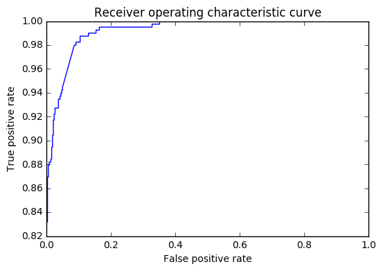

```
Area under ROC curve score = 0.9922665274424068
Accuracy = 0.946360153256705
```

```python
lrm = LogisticRegression_m(n_iter=100)
lrm.fit(train_bow, data_handle.get_target(kind='train'))
predi = lrm.predict_proba(test_bow)
fpr, tpr, thresholds = metrics.roc_curve(data_handle.get_target(kind='test'), predi[:, 1])
acc = metrics.accuracy_score(y_pred=lrm.predict(test_bow.toarray()), y_true=data_handle.get_target(kind='test'))
plt.plot(fpr, tpr)
plt.xlabel('False positive rate')
plt.ylabel('True positive rate')
plt.title('Receiver operating characteristic curve')
plt.show()
print('Area under ROC curve score = {}'.format(roc_auc_score(data_handle.get_target(kind='test'), predi[:,1])))
print('Accuracy = {}'.format(acc))
```

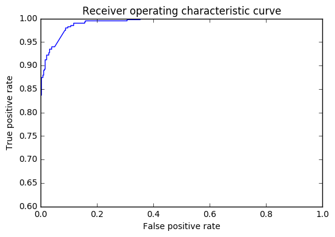

```
Area under ROC curve score = 0.9922665274424068
Accuracy = 0.9514687100893997
```

```python
lrm = LogisticRegression_m(C=0.1, n_iter=100)
lrm.fit(train_bow, data_handle.get_target(kind='train'))
predi = lrm.predict_proba(test_bow)
fpr, tpr, thresholds = metrics.roc_curve(data_handle.get_target(kind='test'), predi[:, 1])
acc = metrics.accuracy_score(y_pred=lrm.predict(test_bow.toarray()), y_true=data_handle.get_target(kind='test'))
plt.plot(fpr, tpr)
plt.xlabel('False positive rate')
plt.ylabel('True positive rate')
plt.title('Receiver operating characteristic curve')
plt.show()
print('Area under ROC curve score = {}'.format(roc_auc_score(data_handle.get_target(kind='test'), predi[:,1])))
print('Accuracy = {}'.format(acc))
```

*Простая логистическая регрессия показывает на тестовых данных отличные значения ROC AUC и Accuracy, с точки зрения Accuracy регрессия со слабой регуляризацией справляется лучше*

*Те же тесты, модель Tf-idf*

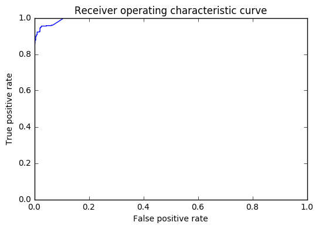

```
Area under ROC curve score = 0.9945310970436598
Accuracy = 0.9565772669220945
```

```python
lrm = LogisticRegression_m(n_iter=100)
lrm.fit(train_tfidf, data_handle.get_target(kind='train'))
predi = lrm.predict_proba(test_tfidf)
fpr, tpr, thresholds = metrics.roc_curve(data_handle.get_target(kind='test'), predi[:, 1])
acc = metrics.accuracy_score(y_pred=lrm.predict(test_tfidf.toarray()), y_true=data_handle.get_target(kind='test'))
plt.plot(fpr, tpr)
plt.xlabel('False positive rate')
plt.ylabel('True positive rate')
plt.title('Receiver operating characteristic curve')
plt.show()
print('Area under ROC curve score = {}'.format(roc_auc_score(data_handle.get_target(kind='test'), predi[:,1])))
print('Accuracy = {}'.format(acc))
```

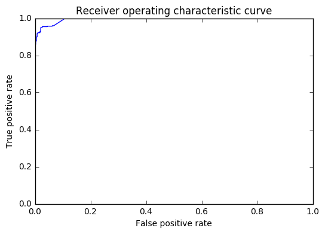

```
Area under ROC curve score = 0.9945898322782745
Accuracy = 0.9629629629629629
```

```python
lrm = LogisticRegression_m(C=0.1, n_iter=100)
lrm.fit(train_tfidf, data_handle.get_target(kind='train'))
predi = lrm.predict_proba(test_tfidf)
fpr, tpr, thresholds = metrics.roc_curve(data_handle.get_target(kind='test'), predi[:, 1])
acc = metrics.accuracy_score(y_pred=lrm.predict(test_tfidf.toarray()), y_true=data_handle.get_target(kind='test'))
plt.plot(fpr, tpr)
plt.xlabel('False positive rate')
plt.ylabel('True positive rate')
plt.title('Receiver operating characteristic curve')
plt.show()
print('Area under ROC curve score = {}'.format(roc_auc_score(data_handle.get_target(kind='test'), predi[:,1])))
print('Accuracy = {}'.format(acc))
```

*Все метрики выше на модели tf-idf. Теперь обучим ряд классификаторов из фреймворка scikit-learn. Зададим ниже список моделей и сетки параметров для поиска наилучшей модели. Примечание: GridSearchCV, использующаяся в написанном выше классе ModelBuilder автоматически выполняет выбор модели с помощью кросс-валидации на K фолдов*

```python
# Воспользуемся реализациями Logistic Regression, Random Forest Classifier и Support Vector Machines
models = [LogisticRegression(), RandomForestClassifier(), SVC()]
models_names = ['Logistic Regression', 'Random Forest', 'Support Vector Machines']
param_grids = [{'C': [10**x for x in range(-3, 2)], 'class_weight': [None, 'balanced'], 'random_state': [0]},
               {'n_estimators': [100, 200, 300], 'max_depth': [5, 8, None],
                'class_weight': [None, 'balanced'], 'random_state': [0]},
                {'C': [1, 10], 'probability': [True], 'decision_function_shape': ['ovr'],
                 'random_state': [0]}]
```

*Сначала bag of words*

```
For Logistic Regression the score is 0.9532710280373832 with parameters {'random_state': 0, 'C': 0.001, 'class_weight': None}
For Random Forest the score is 0.9507221750212405 with parameters {'n_estimators': 300, 'random_state': 0, 'max_depth': None, 'class_weight': None}
For Support Vector Machines the score is 0.8343245539507221 with parameters {'random_state': 0, 'C': 10, 'probability': True, 'decision_function_shape': 'ovr'}
The best estimator is LogisticRegression(C=0.001, class_weight=None, dual=False, fit_intercept=True,
          intercept_scaling=1, max_iter=100, multi_class='ovr', n_jobs=1,
          penalty='l2', random_state=0, solver='liblinear', tol=0.0001,
          verbose=0, warm_start=False)
with accuracy = 0.9532710280373832
             precision    recall  f1-score   support

          0       0.90      0.97      0.94       385
          1       0.97      0.89      0.93       398

avg / total       0.94      0.93      0.93       783
```

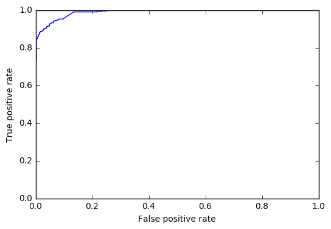

```
Area under ROC curve score = 0.9888859883834757
Accuracy = 0.933588761174968
```

```python
builder = ModelBuilder(cv_folds=10, models=models, models_names=models_names, param_grids=param_grids)
builder.fit(train=train_bow, target=data_handle.get_target(kind='train'))
builder.test_and_report(test=test_bow, target=data_handle.get_target(kind='test'))
```

*Теперь tf-idf*

```
For Logistic Regression the score is 0.9719626168224299 with parameters {'random_state': 0, 'C': 10, 'class_weight': None}
For Random Forest the score is 0.9490229396771452 with parameters {'n_estimators': 300, 'random_state': 0, 'max_depth': None, 'class_weight': None}
The best estimator is LogisticRegression(C=10, class_weight=None, dual=False, fit_intercept=True,
          intercept_scaling=1, max_iter=100, multi_class='ovr', n_jobs=1,
          penalty='l2', random_state=0, solver='liblinear', tol=0.0001,
          verbose=0, warm_start=False)
with accuracy = 0.9719626168224299
             precision    recall  f1-score   support

          0       0.93      0.99      0.96       385
          1       0.99      0.93      0.96       398

avg / total       0.96      0.96      0.96       783
```

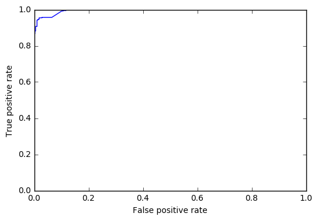

```
Area under ROC curve score = 0.994824773216733
Accuracy = 0.9604086845466155
```

```python
builder = ModelBuilder(cv_folds=10, models=models[0:2], models_names=models_names[0:2], param_grids=param_grids[0:2])
builder.fit(train=train_tfidf, target=data_handle.get_target(kind='train'))
builder.test_and_report(test=test_tfidf, target=data_handle.get_target(kind='test'))
```

*Тесты показывают, что логистическая регрессия со слабой регуляризацией хорошо справляется с классификацией текстов данных двух тематик. Использование более сложной векторной модели tf-idf улучшает точность прогноза*